# R Notebook

```r
library(tidyverse)
library(janitor)
library(fable)
library(tsibble)
```

```r
regional_domestic_tourism_clean
```

| area | year | measurement | units | value | region_of_residence | breakdown_of_domestic_tourism |
| --- | --- | --- | --- | --- | --- | --- |
| West Dunbartonshire | 2016-2018 | Count | million pounds (GBP) | 8 | England | Expenditure |
| West Dunbartonshire | 2015-2017 | Count | Thousand Nights | 140 | All of GB | Nights |
| West Dunbartonshire | 2015-2017 | Count | million pounds (GBP) | 8 | England | Expenditure |
| West Dunbartonshire | 2017-2019 | Count | Thousand Nights | 76 | England | Nights |
| West Dunbartonshire | 2009-2011 | Count | Thousand Visits | 68 | Scotland | Visits |
| West Dunbartonshire | 2016-2018 | Count | Thousand Nights | 59 | Scotland | Nights |
| West Dunbartonshire | 2016-2018 | Count | million pounds (GBP) | 4 | Scotland | Expenditure |
| West Dunbartonshire | 2013-2015 | Count | Thousand Visits | 32 | Scotland | Visits |
| West Dunbartonshire | 2012-2014 | Count | million pounds (GBP) | 6 | England | Expenditure |
| West Dunbartonshire | 2015-2017 | Count | Thousand Visits | 28 | England | Visits |

[output cut: 990 more lines]

```r
scottish_accomodation_occupancy_clean
```

| area | year | measurement | units | value | accommodation_type_and_occupancy | weekday_weekend | size_of_accommodation | location |
| --- | --- | --- | --- | --- | --- | --- | --- | --- |
| Scotland | 2012 | Percent | Percentage | 52.32 | Guest House/B&B - Room Occupancy | All | All | Accessible Small Towns |
| Scotland | 2015 | Percent | Percentage | 49.18 | Guest House/B&B - Room Occupancy | All | All | Large Urban Areas |
| Scotland | 2018 | Percent | Percentage | 63.57 | Guest House/B&B - Room Occupancy | All | All | Large Urban Areas |
| Scotland | 2013 | Percent | Percentage | 53.35 | Guest House/B&B - Room Occupancy | All | All | Accessible Rural |
| Scotland | 2018 | Percent | Percentage | 40.45 | Guest House/B&B - Room Occupancy | All | All | Accessible Rural |
| Scotland | 2019 | Percent | Percentage | 43.93 | Guest House/B&B - Room Occupancy | All | All | Accessible Small Towns |
| Scotland | 2016 | Percent | Percentage | 38.76 | Guest House/B&B - Room Occupancy | All | Rooms: 01-03 | All |
| Scotland | 2017 | Percent | Percentage | 60.24 | Guest House/B&B - Room Occupancy | All | All | Other Urban Areas |
| Scotland | 2016 | Percent | Percentage | 45.44 | Guest House/B&B - Room Occupancy | All | All | Other Urban Areas |
| Scotland | 2015 | Percent | Percentage | 46.54 | Guest House/B&B - Room Occupancy | All | All | Remote Rural |

[output cut: 701 more lines]

```r
tourism_day_visits_activities_clean
```

| area | year | measurement | units | value | tourism_activity | breakdown_of_domestic_tourism |
| --- | --- | --- | --- | --- | --- | --- |
| Scotland | 2019 | Count | million pounds (GBP) | 1662 | Shopping for items that you do not regularly buy | Expenditure |
| Scotland | 2016 | Count | million pounds (GBP) | 469 | Watched live sporting events (not on TV) | Expenditure |
| Scotland | 2014 | Count | million pounds (GBP) | 892 | Night out to a bar, pub and/or club | Expenditure |
| Scotland | 2017 | Count | million pounds (GBP) | 354 | Special personal events e.g. wedding, graduation | Expenditure |
| Scotland | 2015 | Count | million pounds (GBP) | 400 | Watched live sporting events (not on TV) | Expenditure |
| Scotland | 2014 | Count | million pounds (GBP) | 421 | Watched live sporting events (not on TV) | Expenditure |
| Scotland | 2013 | Count | million pounds (GBP) | 243 | Watched live sporting events (not on TV) | Expenditure |
| Scotland | 2015 | Count | million pounds (GBP) | 264 | Leisure activities e.g. hobbies & evening classes | Expenditure |
| Scotland | 2018 | Count | million pounds (GBP) | 285 | Leisure activities e.g. hobbies & evening classes | Expenditure |
| Scotland | 2014 | Count | million pounds (GBP) | 1536 | Shopping for items that you do not regularly buy | Expenditure |

[output cut: 214 more lines]

```r
tourism_day_visits_demmographics_clean
```

| area | year | measurement | units | value | breakdown_of_domestic_tourism | age | marital_status | gender | employment_status | children | access_to_car | social_grade |
| --- | --- | --- | --- | --- | --- | --- | --- | --- | --- | --- | --- | --- |
| Scotland | 2013 | Count | Million Visits | 22 | Visits | 45-54 years | All | All | All | All | All | All |
| Scotland | 2013 | Count | Million Visits | 58 | Visits | All | All | Male | All | All | All | All |
| Scotland | 2016 | Count | Million Visits | 23 | Visits | 25-34 years | All | All | All | All | All | All |
| Scotland | 2019 | Count | Million Visits | 56 | Visits | All | Not Married | All | All | All | All | All |
| Scotland | 2015 | Count | Million Visits | 52 | Visits | All | Not Married | All | All | All | All | All |
| Scotland | 2015 | Count | Million Visits | 15 | Visits | 45-54 years | All | All | All | All | All | All |
| Scotland | 2018 | Count | Million Visits | 23 | Visits | 65 years and over | All | All | All | All | All | All |
| Scotland | 2018 | Count | Million Visits | 59 | Visits | All | Not Married | All | All | All | All | All |
| Scotland | 2014 | Count | Million Visits | 73 | Visits | All | Married | All | All | All | All | All |
| Scotland | 2016 | Count | Million Visits | 142 | Visits | All | All | All | All | All | All | All |

[output cut: 298 more lines]

```r
tourism_day_visits_location_clean
```

| area | year | measurement | units | value | type_of_location_visited | breakdown_of_domestic_tourism |
| --- | --- | --- | --- | --- | --- | --- |
| Scotland | 2014 | Count | million pounds (GBP) | 186 | Seaside - beach | Expenditure |
| Scotland | 2019 | Count | million pounds (GBP) | 1456 | Small town | Expenditure |
| Scotland | 2016 | Count | million pounds (GBP) | 4916 | All areas | Expenditure |
| Scotland | 2018 | Count | million pounds (GBP) | 5474 | All areas | Expenditure |
| Scotland | 2013 | Count | million pounds (GBP) | 217 | Seaside - beach | Expenditure |
| Scotland | 2018 | Count | million pounds (GBP) | 6 | Seaside - other | Expenditure |
| Scotland | 2018 | Count | million pounds (GBP) | 1234 | Small town | Expenditure |
| Scotland | 2015 | Count | million pounds (GBP) | 230 | Seaside resort or town | Expenditure |
| Scotland | 2016 | Count | million pounds (GBP) | 302 | Seaside resort or town | Expenditure |
| Scotland | 2019 | Count | million pounds (GBP) | 359 | Seaside resort or town | Expenditure |

[output cut: 102 more lines]

```r
tourism_day_visits_transport_clean
```

| area | year | measurement | units | value | method_of_travel | breakdown_of_domestic_tourism |
| --- | --- | --- | --- | --- | --- | --- |
| Scotland | 2018 | Count | million pounds (GBP) | 251.8 | Walked | Expenditure |
| Scotland | 2018 | Count | million pounds (GBP) | 1.8 | Caravan/Campervan | Expenditure |
| Scotland | 2014 | Count | million pounds (GBP) | 97.8 | Walked | Expenditure |
| Scotland | 2017 | Count | million pounds (GBP) | 168.8 | Walked | Expenditure |
| Scotland | 2018 | Count | million pounds (GBP) | 193.1 | Plane | Expenditure |
| Scotland | 2015 | Count | million pounds (GBP) | 89.4 | Plane | Expenditure |
| Scotland | 2013 | Count | million pounds (GBP) | 36.7 | Plane | Expenditure |
| Scotland | 2016 | Count | million pounds (GBP) | 8.3 | Plane | Expenditure |
| Scotland | 2019 | Count | million pounds (GBP) | 205.8 | Walked | Expenditure |
| Scotland | 2014 | Count | million pounds (GBP) | 21.8 | Boat/Ship/Ferry | Expenditure |

[output cut: 226 more lines]

[output not shown]

[output cut: 292 more lines]

*varios*

```r
tourism_day_visits_demmographics %>%
  select(date_code,units,value,breakdown_of_domestic_tourism,age,social_grade) %>%
  group_by(date_code,age,units) %>%
  #filter(units == 'million pounds(GBP)') %>%
  arrange(date_code)
```

| date_code | units | value | breakdown_of_domestic_tourism | age | social_grade |
| --- | --- | --- | --- | --- | --- |
| 2013 | Million Visits | 22 | Visits | 45-54 years | All |
| 2013 | Million Visits | 58 | Visits | All | All |
| 2013 | Million Visits | 19 | Visits | 55-64 years | All |
| 2013 | Million Visits | 23 | Visits | 65 years and over | All |
| 2013 | Million Visits | 18 | Visits | 35-44 years | All |
| 2013 | Million Visits | 21 | Visits | 25-34 years | All |
| 2013 | Million Visits | 75 | Visits | All | All |
| 2013 | million pounds (GBP) | 522 | Expenditure | All | DE |
| 2013 | million pounds (GBP) | 994 | Expenditure | 25-34 years | All |
| 2013 | Million Visits | 48 | Visits | All | All |

[output cut: 298 more lines]

Missing where is spent the money?Need another table!!!!!!!!

```r
tourism_day_visits_demmographics %>%
  select(date_code,units,value,breakdown_of_domestic_tourism,age,social_grade) %>%
  group_by(date_code,age,breakdown_of_domestic_tourism) %>%
  filter(breakdown_of_domestic_tourism == 'Expenditure') %>%
  arrange(date_code)
```

| date_code | units | value | breakdown_of_domestic_tourism | age | social_grade |
| --- | --- | --- | --- | --- | --- |
| 2013 | million pounds (GBP) | 522 | Expenditure | All | DE |
| 2013 | million pounds (GBP) | 994 | Expenditure | 25-34 years | All |
| 2013 | million pounds (GBP) | 1319 | Expenditure | All | All |
| 2013 | million pounds (GBP) | 3328 | Expenditure | All | All |
| 2013 | million pounds (GBP) | 2257 | Expenditure | All | All |
| 2013 | million pounds (GBP) | 1076 | Expenditure | All | C2 |
| 2013 | million pounds (GBP) | 2389 | Expenditure | All | All |
| 2013 | million pounds (GBP) | 1600 | Expenditure | All | AB |
| 2013 | million pounds (GBP) | 578 | Expenditure | All | All |
| 2013 | million pounds (GBP) | 4069 | Expenditure | All | All |

[output cut: 144 more lines]

```r
tourism_demographic_location_activities %>%
  select(year,units,value,breakdown_of_domestic_tourism,age, tourism_activity,type_of_location_visited) %>%
  group_by(year,age,breakdown_of_domestic_tourism) %>%
  filter(breakdown_of_domestic_tourism == 'Expenditure') %>%
  arrange(year,desc (value))
```

| year | units | value | breakdown_of_domestic_tourism | age | tourism_activity | type_of_location_visited |
| --- | --- | --- | --- | --- | --- | --- |
| 2013 | million pounds (GBP) | 4647 | Expenditure | All | All | All areas |
| 2013 | million pounds (GBP) | 4069 | Expenditure | All | NA | NA |
| 2013 | million pounds (GBP) | 3328 | Expenditure | All | NA | NA |
| 2013 | million pounds (GBP) | 3092 | Expenditure | All | NA | NA |
| 2013 | million pounds (GBP) | 2894 | Expenditure | All | NA | NA |
| 2013 | million pounds (GBP) | 2850 | Expenditure | NA | NA | City/large town |
| 2013 | million pounds (GBP) | 2389 | Expenditure | All | NA | NA |
| 2013 | million pounds (GBP) | 2257 | Expenditure | All | NA | NA |
| 2013 | million pounds (GBP) | 1675 | Expenditure | NA | Went out for a meal | NA |
| 2013 | million pounds (GBP) | 1600 | Expenditure | All | NA | NA |

[output cut: 296 more lines]

*Ejemplos* bar_char

Problem, only X

[figure not shown]

```r
scottish_accomodation_occupancy_clean %>%
  ggplot(aes( x = accommodation_type_and_occupancy))+
  geom_bar(fill = "light blue", colour = "red")
```

```
                 _ANSWWERS_
```

Definition of a tourism activity:

Q1 Value of the tourism for Scotland

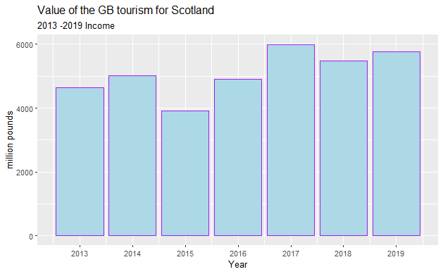

```r
tourism_day_visits_activities_clean %>%
  select(year,units,value,tourism_activity) %>%
  filter(tourism_activity == 'All') %>%
  filter(units == 'million pounds (GBP)') %>%
  arrange(desc(value)) %>%
  ggplot(aes( x = year, y = value))+
  geom_col(fill = "light blue", colour = "purple", position = 'dodge')+
  labs(title =  'Value of the GB tourism for Scotland', subtitle = '2013 -2019 Income', x = 'Year', y = 'million pounds' )+
  scale_x_continuous(breaks = 2013:2019)
```

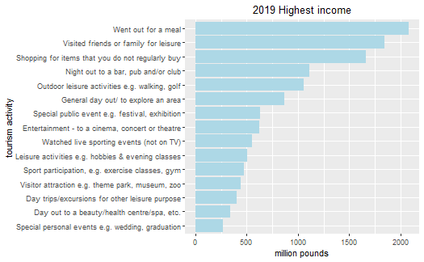

```r
tourism_day_visits_activities_clean %>%
  select(year,units,value,tourism_activity, breakdown_of_domestic_tourism) %>%
  filter(tourism_activity != 'All') %>%
  filter(breakdown_of_domestic_tourism =='Expenditure') %>%
  filter(year == 2019) %>%
  arrange(desc(year)) %>%
   ggplot(aes( x =reorder(tourism_activity,value), y = value))+
  geom_col(fill = "light blue", #colour = "purple",
           position = 'dodge')+
  labs(title = '2019 Highest income' )+
  xlab('tourism activity' )+
  ylab('million pounds' )+
  coord_flip()
```

```r
NA
```

“S”pending 3 or more hours out of the home”

Q1 SECOND PART *What kind of tourism activity generates the highest income for Scotland?*

```r
tourism_day_visits_activities_clean %>%
  select(year,units,value,tourism_activity) %>%
  arrange(desc(value))
```

| year | units | value | tourism_activity |
| --- | --- | --- | --- |
| 2017 | million pounds (GBP) | 5995 | All |
| 2019 | million pounds (GBP) | 5777 | All |
| 2018 | million pounds (GBP) | 5474 | All |
| 2014 | million pounds (GBP) | 5020 | All |
| 2016 | million pounds (GBP) | 4916 | All |
| 2013 | million pounds (GBP) | 4647 | All |
| 2015 | million pounds (GBP) | 3922 | All |
| 2017 | million pounds (GBP) | 2208 | Went out for a meal |
| 2019 | million pounds (GBP) | 2078 | Went out for a meal |
| 2014 | million pounds (GBP) | 1966 | Went out for a meal |

[output cut: 214 more lines]

```r
NA
```

*Filter by year*

```r
tourism_day_visits_activities_clean %>%
  select(year,units,value,tourism_activity) %>%
  filter(year == 2019) %>%
  arrange(desc(value))
```

| year | units | value | tourism_activity |
| --- | --- | --- | --- |
| 2019 | million pounds (GBP) | 5777 | All |
| 2019 | million pounds (GBP) | 2078 | Went out for a meal |
| 2019 | million pounds (GBP) | 1841 | Visited friends or family for leisure |
| 2019 | million pounds (GBP) | 1662 | Shopping for items that you do not regularly buy |
| 2019 | million pounds (GBP) | 1111 | Night out to a bar, pub and/or club |
| 2019 | million pounds (GBP) | 1059 | Outdoor leisure activities e.g. walking, golf |
| 2019 | million pounds (GBP) | 869 | General day out/ to explore an area |
| 2019 | million pounds (GBP) | 629 | Special public event e.g. festival, exhibition |
| 2019 | million pounds (GBP) | 620 | Entertainment - to a cinema, concert or theatre |
| 2019 | million pounds (GBP) | 551 | Watched live sporting events (not on TV) |

[output cut: 22 more lines]

*Filter by year* between 2019 -2013

```r
tourism_day_visits_activities %>%
  select(date_code,units,value,tourism_activity) %>%
  filter(date_code == 2015) %>%
   arrange(desc(value))
```

| date_code | units | value | tourism_activity |
| --- | --- | --- | --- |
| 2015 | million pounds (GBP) | 3922 | All |
| 2015 | million pounds (GBP) | 1631 | Went out for a meal |
| 2015 | million pounds (GBP) | 1186 | Visited friends or family for leisure |
| 2015 | million pounds (GBP) | 1033 | Shopping for items that you do not regularly buy |
| 2015 | million pounds (GBP) | 876 | Night out to a bar, pub and/or club |
| 2015 | million pounds (GBP) | 647 | Outdoor leisure activities e.g. walking, golf |
| 2015 | million pounds (GBP) | 593 | Entertainment - to a cinema, concert or theatre |
| 2015 | million pounds (GBP) | 506 | General day out/ to explore an area |
| 2015 | million pounds (GBP) | 400 | Watched live sporting events (not on TV) |
| 2015 | million pounds (GBP) | 392 | Special public event e.g. festival, exhibition |

[output cut: 22 more lines]

Q2 *Which kind of activity generates the most visits to sites?*

First. where go people and where they spend their money

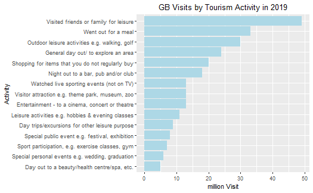

```r
tourism_day_visits_activities_clean %>%
  filter(breakdown_of_domestic_tourism != 'Expenditure') %>%
  filter(year == 2019) %>%
  filter(tourism_activity != 'All') %>%
   arrange(desc(value)) %>%
ggplot(aes( x =reorder(tourism_activity,value), y = value))+
  geom_col(fill = "light blue", #colour = "purple",
           position = 'dodge')+
  labs(title = 'GB Visits by Tourism Activity in 2019' )+
  xlab('Activity' )+
  ylab('million Visit' )+
  coord_flip()
```

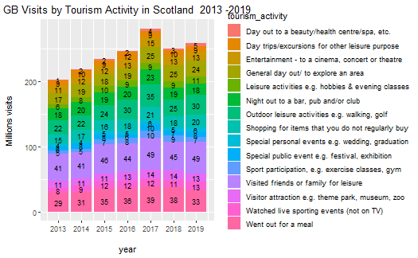

```r
tourism_day_visits_activities_clean %>%
  filter(breakdown_of_domestic_tourism != 'Expenditure') %>%
  filter(tourism_activity != 'All') %>%
   arrange(desc(value)) %>%
ggplot(aes( x = year, y = value, fill = tourism_activity, label = value))+
  geom_bar(stat = 'identity')+
  geom_text(size = 3, position = position_stack(vjust = 0.5))+
labs(
    title = "GB Visits by Tourism Activity in Scotland  2013 -2019",
    x = "\nyear",
    y = "Millions visits\n") +
   scale_x_continuous(breaks = 2013:2019)+
  theme_update(plot.title = element_text(hjust = 0.445))
```

Location!!!!!

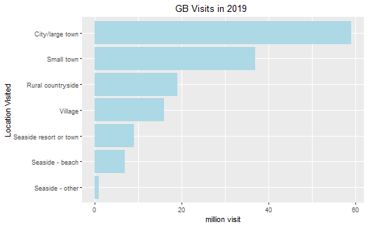

```r
tourism_day_visits_location_clean %>%
  select(year, value, type_of_location_visited, breakdown_of_domestic_tourism) %>%
  filter(breakdown_of_domestic_tourism != 'Expenditure') %>%
  filter(type_of_location_visited != 'All areas') %>%
  filter(year == 2019) %>%
   arrange(desc(value)) %>%
  ggplot(aes( x =reorder(type_of_location_visited,value), y = value))+
  geom_col(fill = "light blue", #colour = "purple",
           position = 'dodge')+
  labs(title = 'GB Visits in 2019' )+
  xlab('Location Visited' )+
  ylab('million visit' )+
  coord_flip()
```

```r
NA
```

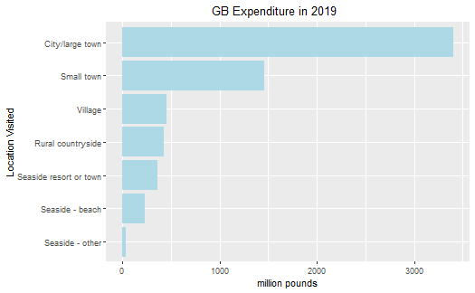

```r
tourism_day_visits_location_clean %>%
  select(year, value, type_of_location_visited, breakdown_of_domestic_tourism) %>%
  filter(breakdown_of_domestic_tourism != 'Visits') %>%
  filter(type_of_location_visited != 'All areas') %>%
  filter(year == 2019) %>%
   arrange(desc(value)) %>%
  ggplot(aes( x =reorder(type_of_location_visited,value), y = value))+
  geom_col(fill = "light blue", #colour = "purple",
           position = 'dodge')+
  labs(title = 'GB Expenditure in 2019' )+
  xlab('Location Visited' )+
  ylab('million pounds' )+
  coord_flip()
```

*Answer* Correlation between area visited and millions pounds expenditure for 2019 From 2013 to 2019

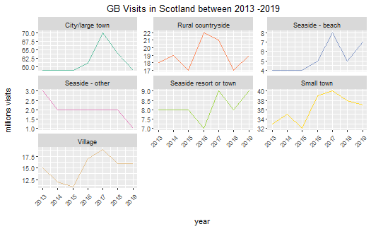

```r
tourism_day_visits_location_clean %>%
  select(year, value, type_of_location_visited, breakdown_of_domestic_tourism) %>%
  filter(breakdown_of_domestic_tourism != 'Expenditure') %>%
  filter(type_of_location_visited != 'All areas') %>%
   ggplot(aes( x = year, y = value, colour = type_of_location_visited))+
  geom_line() +
  facet_wrap(~type_of_location_visited, scales = 'free_y')+
labs(
    title = "GB Visits in Scotland between 2013 -2019",
    x = "\nyear",
    y = "millions visits\n") +
    scale_colour_brewer(guide = "none", palette = "Set2")+
   scale_x_continuous(breaks = 2013:2019)+
  theme(axis.text.x = element_text(angle = 45, hjust = 1))
```

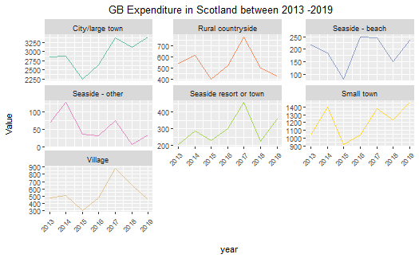

```r
tourism_day_visits_location_clean %>%
  select(year, value, type_of_location_visited, breakdown_of_domestic_tourism) %>%
  filter(breakdown_of_domestic_tourism != 'Visits') %>%
  filter(type_of_location_visited != 'All areas') %>%
   ggplot(aes( x = year, y = value, colour = type_of_location_visited))+
  geom_line() +
  facet_wrap(~type_of_location_visited, scales = 'free_y')+
labs(
    title = "GB Expenditure in Scotland between 2013 -2019",
    x = "\nyear",
    y = "Value\n") +
    scale_colour_brewer(guide = "none", palette = "Set2")+
   scale_x_continuous(breaks = 2013:2019)+
  theme(axis.text.x = element_text(angle = 45, hjust = 1))
```

*Answer* this visualization see the evolution for the period 2013 - 2019 the visits in city/ large town has fallen but the expenditure there has increase in the last year. the Rural countryside shows the opposite the expenditure has decrease but the visits has increase from 2018.

It can be observed that for the year 2019 visits and expenditure are correlated except for the values Village/Rural countryside. In happens as well in the year 2018, 2014

Q2 *Which kind of activity generates the most visits to sites?* /// SECOND PART- REPETITION

```r
tourism_day_visits_location_clean
```

| area | year | measurement | units | value | type_of_location_visited | breakdown_of_domestic_tourism |
| --- | --- | --- | --- | --- | --- | --- |
| Scotland | 2014 | Count | million pounds (GBP) | 186 | Seaside - beach | Expenditure |
| Scotland | 2019 | Count | million pounds (GBP) | 1456 | Small town | Expenditure |
| Scotland | 2016 | Count | million pounds (GBP) | 4916 | All areas | Expenditure |
| Scotland | 2018 | Count | million pounds (GBP) | 5474 | All areas | Expenditure |
| Scotland | 2013 | Count | million pounds (GBP) | 217 | Seaside - beach | Expenditure |
| Scotland | 2018 | Count | million pounds (GBP) | 6 | Seaside - other | Expenditure |
| Scotland | 2018 | Count | million pounds (GBP) | 1234 | Small town | Expenditure |
| Scotland | 2015 | Count | million pounds (GBP) | 230 | Seaside resort or town | Expenditure |
| Scotland | 2016 | Count | million pounds (GBP) | 302 | Seaside resort or town | Expenditure |
| Scotland | 2019 | Count | million pounds (GBP) | 359 | Seaside resort or town | Expenditure |

[output cut: 102 more lines]

```r
tourism_day_visits_location_clean %>%
  select(year, value, type_of_location_visited, breakdown_of_domestic_tourism) %>%
  filter(breakdown_of_domestic_tourism != 'Visits') %>%
  #filter(year == 2014) %>%
   arrange(desc(value))
```

| year | value | type_of_location_visited | breakdown_of_domestic_tourism |
| --- | --- | --- | --- |
| 2017 | 5995 | All areas | Expenditure |
| 2019 | 5777 | All areas | Expenditure |
| 2018 | 5474 | All areas | Expenditure |
| 2014 | 5020 | All areas | Expenditure |
| 2016 | 4916 | All areas | Expenditure |
| 2013 | 4647 | All areas | Expenditure |
| 2015 | 3922 | All areas | Expenditure |
| 2019 | 3400 | City/large town | Expenditure |
| 2017 | 3379 | City/large town | Expenditure |
| 2018 | 3111 | City/large town | Expenditure |

[output cut: 46 more lines]

```r
tourism_day_visits_location_clean %>%
  select(year, value, type_of_location_visited, breakdown_of_domestic_tourism) %>%
  filter(breakdown_of_domestic_tourism != 'Expenditure') %>%
  filter(year == 2014) %>%
   arrange(desc(value))
```

| year | value | type_of_location_visited | breakdown_of_domestic_tourism |
| --- | --- | --- | --- |
| 2014 | 127 | All areas | Visits |
| 2014 | 59 | City/large town | Visits |
| 2014 | 35 | Small town | Visits |
| 2014 | 19 | Rural countryside | Visits |
| 2014 | 12 | Village | Visits |
| 2014 | 8 | Seaside resort or town | Visits |
| 2014 | 4 | Seaside - beach | Visits |
| 2014 | 2 | Seaside - other | Visits |

Q3 *Is there a particular key demographic of visitors we should be focusing on? Who spends the most? Who visits the most?*

```r
tourism_day_visits_demmographics_clean
```

| area | year | measurement | units | value | breakdown_of_domestic_tourism | age | marital_status | gender | employment_status | children | access_to_car | social_grade |
| --- | --- | --- | --- | --- | --- | --- | --- | --- | --- | --- | --- | --- |
| Scotland | 2013 | Count | Million Visits | 22 | Visits | 45-54 years | All | All | All | All | All | All |
| Scotland | 2013 | Count | Million Visits | 58 | Visits | All | All | Male | All | All | All | All |
| Scotland | 2016 | Count | Million Visits | 23 | Visits | 25-34 years | All | All | All | All | All | All |
| Scotland | 2019 | Count | Million Visits | 56 | Visits | All | Not Married | All | All | All | All | All |
| Scotland | 2015 | Count | Million Visits | 52 | Visits | All | Not Married | All | All | All | All | All |
| Scotland | 2015 | Count | Million Visits | 15 | Visits | 45-54 years | All | All | All | All | All | All |
| Scotland | 2018 | Count | Million Visits | 23 | Visits | 65 years and over | All | All | All | All | All | All |
| Scotland | 2018 | Count | Million Visits | 59 | Visits | All | Not Married | All | All | All | All | All |
| Scotland | 2014 | Count | Million Visits | 73 | Visits | All | Married | All | All | All | All | All |
| Scotland | 2016 | Count | Million Visits | 142 | Visits | All | All | All | All | All | All | All |

[output cut: 298 more lines]

# Millions Visits by age.Time range 2013-2019 More visits people under 24.

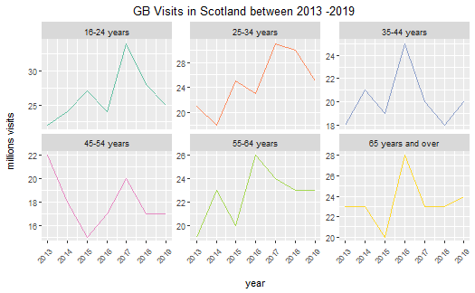

```r
tourism_day_visits_demmographics_clean %>%
  #filter(year == 2019) %>%
  filter(breakdown_of_domestic_tourism =="Visits") %>%
  filter(age != "All") %>%
  arrange(desc(value)) %>%
ggplot(aes( x = year, y = value, colour = age))+
  geom_line() +
  facet_wrap(~age, scales = 'free_y')+
labs(
    title = "GB Visits in Scotland between 2013 -2019",
    x = "\nyear",
    y = "millions visits\n") +
    scale_colour_brewer(guide = "none", palette = "Set2")+
   scale_x_continuous(breaks = 2013:2019)+
  theme(axis.text.x = element_text(angle = 45, hjust = 1))
```

There is not a general tendency each group of age had a prefered year in visit scotland

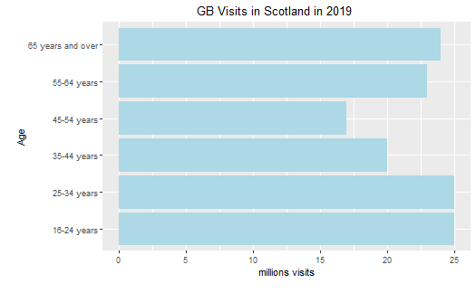

```r
tourism_day_visits_demmographics_clean %>%
  filter(year == 2019) %>%
  filter(breakdown_of_domestic_tourism =="Visits") %>%
  filter(age != "All") %>%
  arrange(desc(value)) %>%
ggplot(aes( x = age, y = value,fill = 'light blue'))+
     geom_col(fill = "light blue",
           position = 'dodge')+
labs(
    title = "GB Visits in Scotland in 2019",
    x = "\nAge",
    y = "millions visits\n") +
  coord_flip()+
  theme_update(plot.title = element_text(hjust = 0.5))
```

```r
NA
```

Years- Age-Millions

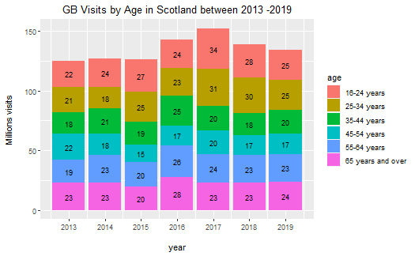

```r
tourism_day_visits_demmographics_clean %>%
  filter(breakdown_of_domestic_tourism =="Visits") %>%
  filter(age != "All") %>%
  arrange(desc(value)) %>%
ggplot(aes( x = year, y = value, fill = age, label = value))+
  geom_bar(stat = 'identity')+
  geom_text(size = 3, position = position_stack(vjust = 0.5))+
labs(
    title = "GB Visits by Age in Scotland between 2013 -2019",
    x = "\nyear",
    y = "Millions visits\n") +
   scale_x_continuous(breaks = 2013:2019)
```

# Millions Expenditure by visitors age. More spend people between 25-34 , 55-56 and 35-44.

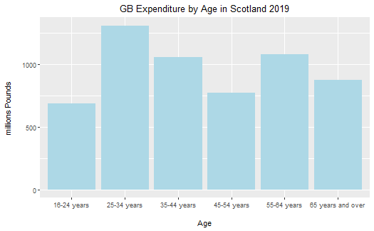

```r
tourism_day_visits_demmographics_clean %>%
  filter(year == 2019) %>%
  filter(breakdown_of_domestic_tourism =='Expenditure') %>%
  filter(age != "All") %>%
  arrange(desc(value)) %>%
  ggplot(aes( x = age, y = value))+
  geom_col(fill = "light blue")+
labs(
    title = "GB Expenditure by Age in Scotland 2019",
    x = "\nAge",
    y = "millions Pounds\n") +
    scale_colour_brewer(guide = "none", palette = "Set2")
```

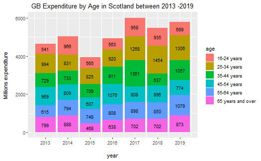

```r
tourism_day_visits_demmographics_clean %>%
  filter(breakdown_of_domestic_tourism =="Expenditure") %>%
  filter(age != "All") %>%
  arrange(desc(value)) %>%
ggplot(aes( x = year, y = value, fill = age, label = value))+
  geom_bar(stat = 'identity')+
  geom_text(size = 3, position = position_stack(vjust = 0.5))+
labs(
    title = "GB Expenditure by Age in Scotland between 2013 -2019",
    x = "\nyear",
    y = "Millions expenditure\n") +
   scale_x_continuous(breaks = 2013:2019)
```

Gender. More Female than Male

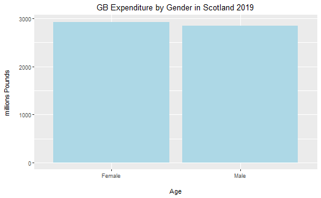

```r
tourism_day_visits_demmographics_clean %>%
  filter(year == 2019) %>%
  filter(breakdown_of_domestic_tourism =='Expenditure') %>%
  filter(gender != "All") %>%
  filter(gender != "All" ) %>%
  arrange(desc(value)) %>%
  ggplot(aes( x = gender, y = value ))+
  geom_col(fill = "light blue")+
labs(
    title = "GB Expenditure by Gender in Scotland 2019",
    x = "\nAge",
    y = "millions Pounds\n") +
    scale_colour_brewer(guide = "none", palette = "Set2")
```

*Answer* Spend more Female than Male in 2019

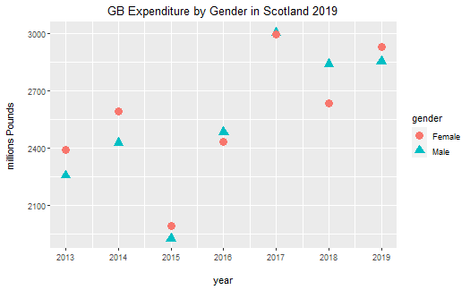

```r
tourism_day_visits_demmographics_clean %>%
  #filter(year == 2019) %>%
  filter(breakdown_of_domestic_tourism =='Expenditure') %>%
  filter(gender != "All") %>%
  filter(gender != "All" ) %>%
  arrange(desc(value)) %>%
  ggplot(aes( x = year, y = value ))+
  geom_point(aes(colour = gender, shape = gender),size = 4)+
labs(
    title = "GB Expenditure by Gender in Scotland 2019",
    x = "\nyear",
    y = "millions Pounds\n") +
    #(guide = "none", palette = "Set2")+
    scale_x_continuous(breaks = 2013:2019)
```

[figure not shown]

```r
tourism_day_visits_demmographics_clean %>%
  filter(year == 2019) %>%
  filter(breakdown_of_domestic_tourism =='Expenditure') %>%
  filter(marital_status !="All") %>%
  arrange(desc(value)) %>%
  ggplot(aes( x = marital_status, y = value ))+
  geom_col(fill = "light blue")+
labs(
    title = "GB Expenditure by Gender in Scotland 2019",
    x = "\nTaken",
    y = "millions Pounds\n") +
    scale_colour_brewer(guide = "none", palette = "Set2")
```

*answer* More married than no married

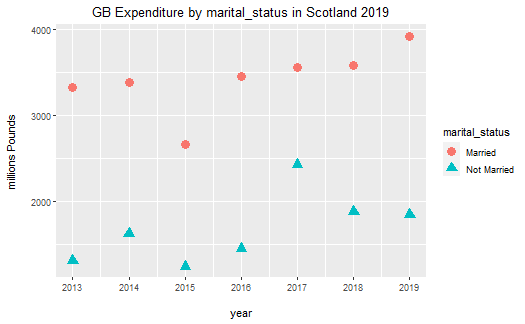

```r
tourism_day_visits_demmographics_clean %>%
 # filter(year == 2019) %>%
  filter(breakdown_of_domestic_tourism =='Expenditure') %>%
  filter(marital_status !="All") %>%
  arrange(desc(value)) %>%
  ggplot(aes( x = year, y = value ))+
  geom_point(aes(colour = marital_status, shape = marital_status),size = 4)+
labs(
    title = "GB Expenditure by marital_status in Scotland 2019",
    x = "\nyear",
    y = "millions Pounds\n") +
    #scale_colour_brewer(guide = "none", palette = "Set2")+
    scale_x_continuous(breaks = 2013:2019)
```

## Childrens? NO! Thanks very interesting!

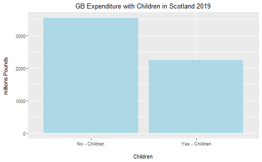

```r
tourism_day_visits_demmographics_clean %>%
  filter(year == 2019) %>%
  filter(breakdown_of_domestic_tourism =='Expenditure') %>%
  filter(children !="All") %>%
  arrange(desc(value)) %>%
  ggplot(aes( x = children, y = value ))+
  geom_col(fill = "light blue")+
labs(
    title = "GB Expenditure with Children in Scotland 2019",
    x = "\nChildren",
    y = "millions Pounds\n") +
    scale_colour_brewer(guide = "none", palette = "Set2")
```

*Answer* Spend more without Kids in 2019

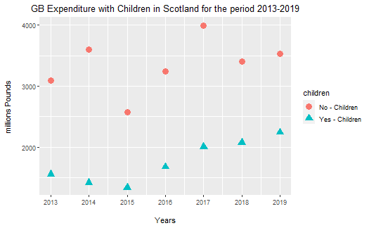

```r
tourism_day_visits_demmographics_clean %>%
  #filter(year == 2019) %>%
  filter(breakdown_of_domestic_tourism =='Expenditure') %>%
  filter(children !="All") %>%
  arrange(desc(value)) %>%
  ggplot(aes( x = year, y = value ))+
  geom_point(aes(colour = children, shape = children),size = 4)+
labs(
    title = "GB Expenditure with Children in Scotland for the period 2013-2019",
    x = "\nYears",
    y = "millions Pounds\n") +
    scale_x_continuous(breaks = 2013:2019)
```

*Answer* Spend more without Kids in all years

## Millions Expenditure by employment_status.

The gross part is, obviously, spend by employed / self-employed persons. We can questioning about the consequences about the fact that 715 millions are spend by unemployed or not working people, maybe this total amount is the reflection of students plus retired people. Segun los datos hay 998 millones que no se saben donde estan o que no han respondido

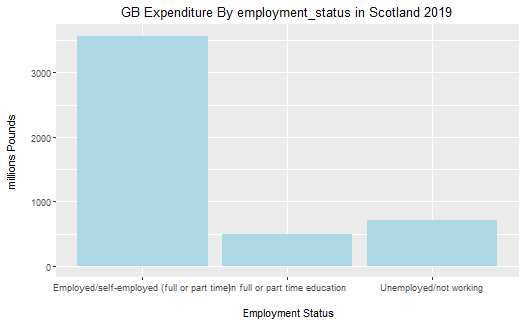

```r
tourism_day_visits_demmographics_clean %>%
  select(area, year,measurement,units,value,breakdown_of_domestic_tourism,employment_status) %>%
  filter(year == 2019) %>%
  filter(breakdown_of_domestic_tourism =='Expenditure') %>%
  filter(employment_status != "All") %>%
  arrange(desc(value)) %>%
  ggplot(aes( x = employment_status, y = value ))+
  geom_col(fill = "light blue")+
labs(
    title = "GB Expenditure By employment_status in Scotland 2019",
    x = "\n Employment Status",
    y = "millions Pounds\n") +
    scale_colour_brewer(guide = "none", palette = "Set2")
```

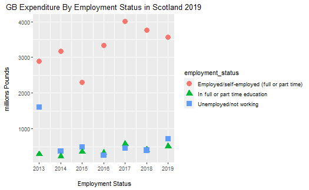

```r
tourism_day_visits_demmographics_clean %>%
  select(area, year,measurement,units,value,breakdown_of_domestic_tourism,employment_status) %>%
  filter(breakdown_of_domestic_tourism =='Expenditure') %>%
  filter(employment_status != "All") %>%
  arrange(desc(value)) %>%
  ggplot(aes( x = year, y = value ))+
  geom_point(aes(colour = employment_status, shape = employment_status),size = 4)+
  labs(
    title = "GB Expenditure By Employment Status in Scotland 2019",
    x = "\n Employment Status",
    y = "millions Pounds\n") +
    scale_x_continuous(breaks = 2013:2019)
```

*Answer* Obvious plot.

Is important the social grade? Is ethical?Funny the most expenditure is the highest grade occupation but the second is in theory the lowest grade occupation ( less money/ less cultured person? assumption)

[figure not shown]

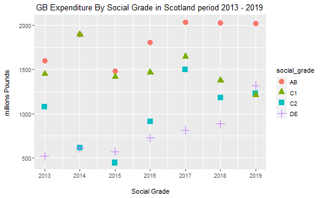

```r
tourism_day_visits_demmographics_clean %>%
  select(area, year,measurement,units,value,breakdown_of_domestic_tourism,social_grade) %>%
  filter(breakdown_of_domestic_tourism =='Expenditure') %>%
  filter(social_grade != "All") %>%
  arrange(desc(value)) %>%
 ggplot(aes( x = year, y = value ))+
   geom_point(aes(colour = social_grade, shape = social_grade),size = 4)+
  labs(
    title = "GB Expenditure By Social Grade in Scotland period 2013 - 2019",
    x = "\n Social Grade",
    y = "millions Pounds\n") +
    scale_x_continuous(breaks = 2013:2019)
```

The obvious for social grade but not the last year. Is it ethical?

*Answer*. so Young couples, maybe more females with good salaries/ highest employment status, high social grade and no children (yet)

Q4 *What type of locations receive the most visits? What kinds of locations do people spend the most in?*

# tourism_day_visits_location_clean + tourism_day_visits_activities_clean = answer question2!!!!!! THere are no enough information to combine ‘tourism activity’ and ‘type of location visited’. Has to be the visualizations in Q2!!

```r
visit_sites_activity
```

| area | year | measurement | units | value | type_of_location_visited | breakdown_of_domestic_tourism | tourism_activity |
| --- | --- | --- | --- | --- | --- | --- | --- |
| Scotland | 2014 | Count | million pounds (GBP) | 186 | Seaside - beach | Expenditure | NA |
| Scotland | 2019 | Count | million pounds (GBP) | 1456 | Small town | Expenditure | NA |
| Scotland | 2016 | Count | million pounds (GBP) | 4916 | All areas | Expenditure | All |
| Scotland | 2018 | Count | million pounds (GBP) | 5474 | All areas | Expenditure | All |
| Scotland | 2013 | Count | million pounds (GBP) | 217 | Seaside - beach | Expenditure | NA |
| Scotland | 2018 | Count | million pounds (GBP) | 6 | Seaside - other | Expenditure | NA |
| Scotland | 2018 | Count | million pounds (GBP) | 1234 | Small town | Expenditure | NA |
| Scotland | 2015 | Count | million pounds (GBP) | 230 | Seaside resort or town | Expenditure | NA |
| Scotland | 2016 | Count | million pounds (GBP) | 302 | Seaside resort or town | Expenditure | NA |
| Scotland | 2019 | Count | million pounds (GBP) | 359 | Seaside resort or town | Expenditure | NA |

[output cut: 292 more lines]

Sites visits by activity. Data from 2013 to 2019

[figure not shown]

```r
visit_sites_activity %>%
  filter(breakdown_of_domestic_tourism == 'Visits') %>%
  filter(type_of_location_visited != 'All areas') %>%
  filter(tourism_activity != c('All', 'NA')) %>%
  #filter(year ==2019) %>%
  arrange(year, tourism_activity) %>%
ggplot(aes( x = type_of_location_visited, y = value))+
  geom_col(fill = "light blue")+
labs(
    title = "GB visits by location  in Scotland 2019",
    x = "\n",
    y = "millions Pounds\n")
```

There is a ‘problem’ the maths doesnt work for 2013 the 124 million visits ‘All areas’ is unequal to the sum of different locations. Without filter NA there are a lot of more information = millions visits lost. I show the first one by year and the first one with tourism activity.

VISITS 2019- 59million visit City/large town unknown tourism_activity (1st) Note: It could be Edinburgh/ Glasgow 2019- 9 Seaside resort or town Day trips/excursions for other leisure purpose tourism_activity (5th) 2018- 64 City/large town unknown tourism_activity (1st) Note: It could be Edinburgh/ Glasgow 2018- 38 Small town Went out for a meal tourism_activity(2nd) 2017- 70 City/large town unknown tourism_activity (1st) Note: It could be Edinburgh/ Glasgow 2017- 21 Rural countryside Shopping for items that you do not regularly buy tourism_activity(3rd) 2016- 61 City/large town unknown tourism_activity (1st) Note: It could be Edinburgh/ Glasgow 2016- 5 Seaside - beach Special personal events e.g. wedding, graduation tourism_activity(6th) 2015- 59 City/large town unknown tourism_activity (1st) Note: It could be Edinburgh/ Glasgow 2015- 11 Village Visitor attraction e.g. theme park, museum, zoo tourism_activity(4th) 2014- 59 million visit City/large town unknown tourism_activity (1st) Note: It could be Edinburgh/ Glasgow (commonwealth games Glasgow) 2014- 19 million visit Rural countryside General day out/ to explore an area tourism_activity(3rd) 2013- 59 million visits City/large town unknown tourism_activity (1st) Note: It could be Edinburgh/ Glasgow 2013- 18 Rural countryside Night out to a bar, pub and/or club tourism_activity(3rd)

EXPENDITURE (1st place and 2nd place)

2019- 3400 million pounds (GBP) City/large town unknown tourism_activity (1st) Note: It could be Edinburgh/ Glasgow  
2019- 1456 Small town unknown tourism_activity (2nd) 2018- 3111 City/large town unknown tourism_activity (1st) Note: It could be Edinburgh/ Glasgow 2018- 1234 Small town unknown tourism_activity (2nd) 2017- 3379 City/large town unknown tourism_activity (1st) Note: It could be Edinburgh/ Glasgow 2017- 1377 Small town unknown tourism_activity (2nd) 2016- 2630 City/large town unknown tourism_activity (1st) Note: It could be Edinburgh/ Glasgow 2016- 1037 Small town unknown tourism_activity (2nd) 2015- 2254 City/large town unknown tourism_activity (1st) Note: It could be Edinburgh/ Glasgow 2015- 914 Small town unknown tourism_activity (2nd) 2014- 2873 City/large town unknown tourism_activity (1st) Note: It could be Edinburgh/ Glasgow 2014- 1398 Small town unknown tourism_activity (2nd) 2013- 2850 City/large town unknown tourism_activity (1st) Note: It could be Edinburgh/ Glasgow 2013- 1035 Small town unknown tourism_activity (2nd)

Only tourism_activity

```r
visit_sites_activity %>%
  filter(breakdown_of_domestic_tourism == 'Visits') %>%
  filter(type_of_location_visited != 'NA') %>%
  filter(tourism_activity != 'NA') %>%
  filter(year== 2013) %>%
  arrange( tourism_activity)
```

| area | year | measurement | units | value | type_of_location_visited | breakdown_of_domestic_tourism | tourism_activity |
| --- | --- | --- | --- | --- | --- | --- | --- |
| Scotland | 2013 | Count | Million Visits | 124 | All areas | Visits | All |
| Scotland | 2013 | Count | Million Visits | 18 | Rural countryside | Visits | Night out to a bar, pub and/or club |
| Scotland | 2013 | Count | Million Visits | 15 | Village | Visits | Shopping for items that you do not regularly buy |
| Scotland | 2013 | Count | Million Visits | 4 | Seaside - beach | Visits | Special personal events e.g. wedding, graduation |
| Scotland | 2013 | Count | Million Visits | 8 | Seaside resort or town | Visits | Watched live sporting events (not on TV) |

Total value of All “types_of_location_visited” (124) is different to the independent sum of the each value, check what they say in the web. But I think the answer is that one person can visited multiple location. It is the same even you dont filter NA.

Q5 *Is there a particular method of travel our visitors arrive by? Some of our locations are remote and not easily accessible by public transport, so this would be good information to have*

In my opinion the data mix to important questions how they arrive to Scotland and how they move around Scotland. As we data only cover GB (England, Scotland, Wales). Which scottish airport has conections with the rest of the Island? At least, Edinburgh and Glasgow have.Travels by plane can take a taxi, car hire or tram (edinburgh) some questions have multiple answers. One visitor/visitors can use different method travel, arrive to an airport city like Edinburgh by plane, go to accommodation by taxi,regular bus or Tram and later walk around the city. Maybe the train is used for move between large/ medium cities and car for small and rural.

```r
tourism_day_visits_transport_clean
```

| area | year | measurement | units | value | method_of_travel | breakdown_of_domestic_tourism |
| --- | --- | --- | --- | --- | --- | --- |
| Scotland | 2018 | Count | million pounds (GBP) | 251.8 | Walked | Expenditure |
| Scotland | 2018 | Count | million pounds (GBP) | 1.8 | Caravan/Campervan | Expenditure |
| Scotland | 2014 | Count | million pounds (GBP) | 97.8 | Walked | Expenditure |
| Scotland | 2017 | Count | million pounds (GBP) | 168.8 | Walked | Expenditure |
| Scotland | 2018 | Count | million pounds (GBP) | 193.1 | Plane | Expenditure |
| Scotland | 2015 | Count | million pounds (GBP) | 89.4 | Plane | Expenditure |
| Scotland | 2013 | Count | million pounds (GBP) | 36.7 | Plane | Expenditure |
| Scotland | 2016 | Count | million pounds (GBP) | 8.3 | Plane | Expenditure |
| Scotland | 2019 | Count | million pounds (GBP) | 205.8 | Walked | Expenditure |
| Scotland | 2014 | Count | million pounds (GBP) | 21.8 | Boat/Ship/Ferry | Expenditure |

[output cut: 226 more lines]

```r
tourism_day_visits_transport_clean %>%
  filter(year == 2019) %>%
  filter(breakdown_of_domestic_tourism =='Visits') %>%
  arrange(desc(value))
```

| area | year | measurement | units | value | method_of_travel | breakdown_of_domestic_tourism |
| --- | --- | --- | --- | --- | --- | --- |
| Scotland | 2019 | Count | Million Visits | 133.6 | All | Visits |
| Scotland | 2019 | Count | Million Visits | 80.0 | Car - own/friends/family | Visits |
| Scotland | 2019 | Count | Million Visits | 15.9 | Train | Visits |
| Scotland | 2019 | Count | Million Visits | 12.7 | Bus or Coach - Regular | Visits |
| Scotland | 2019 | Count | Million Visits | 7.5 | Walked | Visits |
| Scotland | 2019 | Count | Million Visits | 5.7 | Taxi | Visits |
| Scotland | 2019 | Count | Million Visits | 2.5 | Bus or Coach - Organised Tour | Visits |
| Scotland | 2019 | Count | Million Visits | 2.3 | Car - hired | Visits |
| Scotland | 2019 | Count | Million Visits | 1.6 | Tube | Visits |
| Scotland | 2019 | Count | Million Visits | 1.4 | Other | Visits |

[output cut: 6 more lines]

There are few things interesting, 0.5 million visitis arrive by see(boat/ship/ ferry) where is cruise is boat a cruise? ship and ferry can include go to the Islands? only 0.4 take a caravan or campervan but the value of their spend is 24.2 millions of pounds. We can conclude that is minimum visits some Islands such as Mull, Islay, Arran, others such as western Islands , Orkney or Shetlands have airports. Visit the Islands imply more nights and more expenses

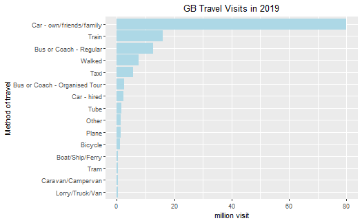

```r
tourism_day_visits_transport_clean %>%
  filter(year == 2019) %>%
  filter(breakdown_of_domestic_tourism =='Visits') %>%
  filter(method_of_travel != 'All') %>%
  arrange(desc(value)) %>%
  ggplot(aes(x =reorder(method_of_travel,value), y = value))+
  geom_col(fill = "light blue", #colour = "purple",
           position = 'dodge')+
  labs(title = 'GB Travel Visits in 2019' )+
  xlab('Method of travel' )+
  ylab('million visit' )+
  coord_flip()
```

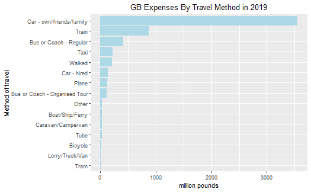

```r
tourism_day_visits_transport_clean %>%
  filter(year == 2019) %>%
  filter(breakdown_of_domestic_tourism =='Expenditure') %>%
   filter(method_of_travel != 'All') %>%
  arrange(desc(value)) %>%
  ggplot(aes(x =reorder(method_of_travel,value), y = value))+
  geom_col(fill = "light blue", #colour = "purple",
           position = 'dodge')+
  labs(title = 'GB Expenses By Travel Method in 2019' )+
  xlab('Method of travel' )+
  ylab('million pounds' )+
  coord_flip()
```

En 2019 el transporte por avion solo trajo poco menos de millon y medio de visitas ( 10 puesto) pero a cambio trajo 123 millones de libras(7 puesto). Planes is more to arrive to any airport and later take a hired vehicle , taxi…. so its a way to arrive to scotland more than travel around the country.

How travel people and their expenditure in relation

Q6 *When looking at regional tourism, what insights can we gain? Where are our visitors from? How do they differ in the money they spend, nights they spend in Scotland, or number of visits they do?*

```r
regional_domestic_tourism_clean
```

| area | year | measurement | units | value | region_of_residence | breakdown_of_domestic_tourism |
| --- | --- | --- | --- | --- | --- | --- |
| West Dunbartonshire | 2016-2018 | Count | million pounds (GBP) | 8 | England | Expenditure |
| West Dunbartonshire | 2015-2017 | Count | Thousand Nights | 140 | All of GB | Nights |
| West Dunbartonshire | 2015-2017 | Count | million pounds (GBP) | 8 | England | Expenditure |
| West Dunbartonshire | 2017-2019 | Count | Thousand Nights | 76 | England | Nights |
| West Dunbartonshire | 2009-2011 | Count | Thousand Visits | 68 | Scotland | Visits |
| West Dunbartonshire | 2016-2018 | Count | Thousand Nights | 59 | Scotland | Nights |
| West Dunbartonshire | 2016-2018 | Count | million pounds (GBP) | 4 | Scotland | Expenditure |
| West Dunbartonshire | 2013-2015 | Count | Thousand Visits | 32 | Scotland | Visits |
| West Dunbartonshire | 2012-2014 | Count | million pounds (GBP) | 6 | England | Expenditure |
| West Dunbartonshire | 2015-2017 | Count | Thousand Visits | 28 | England | Visits |

[output cut: 990 more lines]

Issues : The year is an average of 3 years , All GB means England, Scotland and Wales. But its only, Scotland and England in observations but not Wales and its difficult to substract this country from ‘All GB’

```r
regional_domestic_tourism_clean %>%
  group_by(breakdown_of_domestic_tourism) %>%
  count()
```

| breakdown_of_domestic_tourism | n |
| --- | --- |
| Expenditure | 891 |
| Nights | 891 |
| Visits | 891 |

```r
regional_domestic_tourism_clean %>%
  select( area ,year, value, units,region_of_residence,breakdown_of_domestic_tourism ) %>%
  group_by(year) %>%
  filter(region_of_residence == 'All of GB') %>%
  filter(breakdown_of_domestic_tourism == 'Nights')
```

| area | year | value | units | region_of_residence | breakdown_of_domestic_tourism |
| --- | --- | --- | --- | --- | --- |
| West Dunbartonshire | 2015-2017 | 140 | Thousand Nights | All of GB | Nights |
| West Dunbartonshire | 2016-2018 | 144 | Thousand Nights | All of GB | Nights |
| West Dunbartonshire | 2014-2016 | 128 | Thousand Nights | All of GB | Nights |
| West Dunbartonshire | 2011-2013 | 256 | Thousand Nights | All of GB | Nights |
| West Dunbartonshire | 2009-2011 | 318 | Thousand Nights | All of GB | Nights |
| West Dunbartonshire | 2013-2015 | 118 | Thousand Nights | All of GB | Nights |
| West Dunbartonshire | 2010-2012 | 273 | Thousand Nights | All of GB | Nights |
| West Dunbartonshire | 2017-2019 | 174 | Thousand Nights | All of GB | Nights |
| West Dunbartonshire | 2012-2014 | 192 | Thousand Nights | All of GB | Nights |
| West Lothian | 2016-2018 | 197 | Thousand Nights | All of GB | Nights |

[output cut: 287 more lines]

```r
NA
```

```r
regional_domestic_tourism_clean %>%
  select( area ,year, value, units,region_of_residence,breakdown_of_domestic_tourism ) %>%
  group_by(year) %>%
  filter(region_of_residence == 'England') %>%
  filter(breakdown_of_domestic_tourism == 'Expenditure') %>%
  arrange(year)
```

| area | year | value | units | region_of_residence | breakdown_of_domestic_tourism |
| --- | --- | --- | --- | --- | --- |
| West Dunbartonshire | 2009-2011 | 3 | million pounds (GBP) | England | Expenditure |
| West Lothian | 2009-2011 | 9 | million pounds (GBP) | England | Expenditure |
| Scotland | 2009-2011 | 1644 | million pounds (GBP) | England | Expenditure |
| Clackmannanshire | 2009-2011 | 3 | million pounds (GBP) | England | Expenditure |
| Dumfries and Galloway | 2009-2011 | 96 | million pounds (GBP) | England | Expenditure |
| East Ayrshire | 2009-2011 | 5 | million pounds (GBP) | England | Expenditure |
| East Lothian | 2009-2011 | 8 | million pounds (GBP) | England | Expenditure |
| East Renfrewshire | 2009-2011 | 0 | million pounds (GBP) | England | Expenditure |
| Na h-Eileanan Siar | 2009-2011 | 9 | million pounds (GBP) | England | Expenditure |
| Falkirk | 2009-2011 | 19 | million pounds (GBP) | England | Expenditure |

[output cut: 287 more lines]

```r
regional_domestic_tourism_clean %>%
  select( area ,year, value, units,region_of_residence,breakdown_of_domestic_tourism ) %>%
  filter(year == '2017-2019') %>%
  filter(region_of_residence == 'All of GB') %>%
  filter(area != 'Scotland') %>%
  filter(breakdown_of_domestic_tourism == 'Expenditure') %>%
  arrange(desc(value))
```

| area | year | value | units | region_of_residence | breakdown_of_domestic_tourism |
| --- | --- | --- | --- | --- | --- |
| City of Edinburgh | 2017-2019 | 728 | million pounds (GBP) | All of GB | Expenditure |
| Highland | 2017-2019 | 492 | million pounds (GBP) | All of GB | Expenditure |
| Glasgow City | 2017-2019 | 364 | million pounds (GBP) | All of GB | Expenditure |
| Argyll and Bute | 2017-2019 | 199 | million pounds (GBP) | All of GB | Expenditure |
| Perth and Kinross | 2017-2019 | 158 | million pounds (GBP) | All of GB | Expenditure |
| Dumfries and Galloway | 2017-2019 | 131 | million pounds (GBP) | All of GB | Expenditure |
| Fife | 2017-2019 | 112 | million pounds (GBP) | All of GB | Expenditure |
| Aberdeen City | 2017-2019 | 111 | million pounds (GBP) | All of GB | Expenditure |
| South Ayrshire | 2017-2019 | 82 | million pounds (GBP) | All of GB | Expenditure |
| Stirling | 2017-2019 | 67 | million pounds (GBP) | All of GB | Expenditure |

[output cut: 22 more lines]

Unfortunately no works a Data viz with geom_point to many areas

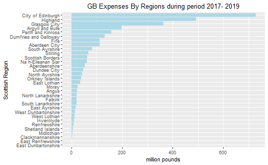

```r
regional_domestic_tourism_clean %>%
  select( area ,year, value, units,region_of_residence,breakdown_of_domestic_tourism ) %>%

  filter(year == '2017-2019') %>%
  filter(region_of_residence == 'All of GB') %>%
  filter(area != 'Scotland') %>%
  filter(breakdown_of_domestic_tourism == 'Expenditure') %>%
  arrange(desc(value)) %>%
   ggplot(aes(x =reorder(area,value), y = value))+
  geom_col(fill = "light blue", #colour = "purple",
           position = 'dodge')+
  labs(title = 'GB Expenses By Regions during period 2017- 2019' )+
  xlab('Scottish Region' )+
  ylab('million pounds' )+
  coord_flip()
```

What could we deduce? it is not how to arrive, the Western Islands ( Na h-Elleanan Siar) is over regions of the ‘Central bell’ it is the offer fro activities

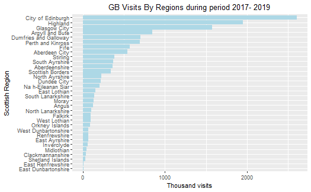

```r
regional_domestic_tourism_clean %>%
  select( area ,year, value, units,region_of_residence,breakdown_of_domestic_tourism ) %>%
  filter(year == '2017-2019') %>%
  filter(region_of_residence == 'All of GB') %>%
  filter(area != 'Scotland') %>%
  filter(breakdown_of_domestic_tourism == 'Visits') %>%
  arrange(desc(value)) %>%
   ggplot(aes(x =reorder(area,value), y = value))+
  geom_col(fill = "light blue", #colour = "purple",
           position = 'dodge')+
  labs(title = 'GB Visits By Regions during period 2017- 2019' )+
  xlab('Scottish Region' )+
  ylab('Thousand visits' )+
  coord_flip()
```

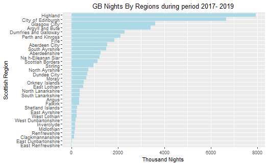

```r
regional_domestic_tourism_clean %>%
  select( area ,year, value, units,region_of_residence,breakdown_of_domestic_tourism ) %>%
  filter(year == '2017-2019') %>%
  filter(region_of_residence == 'All of GB') %>%
  filter(area != 'Scotland') %>%
  filter(breakdown_of_domestic_tourism == 'Nights') %>%
  arrange(desc(value)) %>%
   ggplot(aes(x =reorder(area,value), y = value))+
  geom_col(fill = "light blue", #colour = "purple",
           position = 'dodge')+
  labs(title = 'GB Nights By Regions during period 2017- 2019' )+
  xlab('Scottish Region' )+
  ylab('Thousand Nights' )+
  coord_flip()
```

The nights are possible related to what can you do there? The offer, obviously for Highland or the big cities is more than for areas like the ’ central bell’ where the normal should be to stay in edinburgh/Glasgow and from there travel and back at the same day.

```r
scottish_accomodation_occupancy_clean
```

| area | year | measurement | units | value | accommodation_type_and_occupancy | weekday_weekend | size_of_accommodation | location |
| --- | --- | --- | --- | --- | --- | --- | --- | --- |
| Scotland | 2012 | Percent | Percentage | 52.32 | Guest House/B&B - Room Occupancy | All | All | Accessible Small Towns |
| Scotland | 2015 | Percent | Percentage | 49.18 | Guest House/B&B - Room Occupancy | All | All | Large Urban Areas |
| Scotland | 2018 | Percent | Percentage | 63.57 | Guest House/B&B - Room Occupancy | All | All | Large Urban Areas |
| Scotland | 2013 | Percent | Percentage | 53.35 | Guest House/B&B - Room Occupancy | All | All | Accessible Rural |
| Scotland | 2018 | Percent | Percentage | 40.45 | Guest House/B&B - Room Occupancy | All | All | Accessible Rural |
| Scotland | 2019 | Percent | Percentage | 43.93 | Guest House/B&B - Room Occupancy | All | All | Accessible Small Towns |
| Scotland | 2016 | Percent | Percentage | 38.76 | Guest House/B&B - Room Occupancy | All | Rooms: 01-03 | All |
| Scotland | 2017 | Percent | Percentage | 60.24 | Guest House/B&B - Room Occupancy | All | All | Other Urban Areas |
| Scotland | 2016 | Percent | Percentage | 45.44 | Guest House/B&B - Room Occupancy | All | All | Other Urban Areas |
| Scotland | 2015 | Percent | Percentage | 46.54 | Guest House/B&B - Room Occupancy | All | All | Remote Rural |

[output cut: 701 more lines]

```r
scottish_accomodation_occupancy_clean %>%
  group_by(accommodation_type_and_occupancy) %>%
  summarise()
```

| accommodation_type_and_occupancy |
| --- |
| Caravan & Camping Parks - Pitch Occupancy |
| Guest House/B&B - Bed Occupancy |
| Guest House/B&B - Room Occupancy |
| Hostels - Bed Occupancy |
| Hotels - Bed Occupancy |
| Hotels - Room Occupancy |
| Self Catering - Unit Occupancy |

```r
scottish_accomodation_occupancy_clean %>%
  group_by(weekday_weekend) %>%
  summarise()
```

| weekday_weekend |
| --- |
| All |
| Weekday |
| Weekend |

during weekdays and weekends

```r
scottish_accomodation_occupancy_clean %>%
  select(area,year,value,accommodation_type_and_occupancy,location, weekday_weekend) %>%
  filter(year == 2019) %>%
  filter(location == 'All') %>%
  filter(weekday_weekend == 'Weekend') %>%
  group_by(accommodation_type_and_occupancy) %>%
  arrange(desc(value),accommodation_type_and_occupancy)
```

| area | year | value | accommodation_type_and_occupancy | location | weekday_weekend |
| --- | --- | --- | --- | --- | --- |
| Scotland | 2019 | 70.24 | Hotels - Room Occupancy | All | Weekend |
| Scotland | 2019 | 56.02 | Guest House/B&B - Room Occupancy | All | Weekend |
| Scotland | 2019 | 54.98 | Hotels - Bed Occupancy | All | Weekend |
| Scotland | 2019 | 49.30 | Guest House/B&B - Bed Occupancy | All | Weekend |
| Scotland | 2019 | 38.77 | Caravan & Camping Parks - Pitch Occupancy | All | Weekend |
| Scotland | 2019 | 37.09 | Hostels - Bed Occupancy | All | Weekend |

```r
  scottish_accomodation_occupancy_clean %>%
  select(area,year,value,accommodation_type_and_occupancy,location, weekday_weekend) %>%
  filter(year == 2019) %>%
  filter(location == 'All') %>%
  filter(weekday_weekend == 'Weekday') %>%
  group_by(accommodation_type_and_occupancy) %>%
  arrange(desc(value),accommodation_type_and_occupancy)
```

| area | year | value | accommodation_type_and_occupancy | location | weekday_weekend |
| --- | --- | --- | --- | --- | --- |
| Scotland | 2019 | 72.51 | Hotels - Room Occupancy | All | Weekday |
| Scotland | 2019 | 50.93 | Guest House/B&B - Room Occupancy | All | Weekday |
| Scotland | 2019 | 49.13 | Hotels - Bed Occupancy | All | Weekday |
| Scotland | 2019 | 41.32 | Guest House/B&B - Bed Occupancy | All | Weekday |
| Scotland | 2019 | 30.30 | Caravan & Camping Parks - Pitch Occupancy | All | Weekday |
| Scotland | 2019 | 22.00 | Hostels - Bed Occupancy | All | Weekday |

Note:/ question self-catering is rent a flat/ airB&B? The preference of the accommodation is linked to location and its offer available.

```r
scottish_accomodation_occupancy_clean %>%
  select(area,year,value,accommodation_type_and_occupancy,location,weekday_weekend) %>%
  filter(year == 2019) %>%
  filter(location == 'Large Urban Areas') %>%
  group_by(accommodation_type_and_occupancy) %>%
  arrange(desc(value),accommodation_type_and_occupancy)
```

| area | year | value | accommodation_type_and_occupancy | location | weekday_weekend |
| --- | --- | --- | --- | --- | --- |
| Scotland | 2019 | 75.57 | Hotels - Room Occupancy | Large Urban Areas | All |
| Scotland | 2019 | 70.86 | Guest House/B&B - Room Occupancy | Large Urban Areas | All |
| Scotland | 2019 | 65.28 | Guest House/B&B - Bed Occupancy | Large Urban Areas | All |
| Scotland | 2019 | 64.70 | Hostels - Bed Occupancy | Large Urban Areas | All |
| Scotland | 2019 | 57.15 | Hotels - Bed Occupancy | Large Urban Areas | All |
| Scotland | 2019 | 34.58 | Self Catering - Unit Occupancy | Large Urban Areas | All |
| Scotland | 2019 | 34.30 | Caravan & Camping Parks - Pitch Occupancy | Large Urban Areas | All |

```r
scottish_accomodation_occupancy_clean %>%
  select(area,year,value,accommodation_type_and_occupancy,location) %>%
  filter(year == 2019) %>%
  filter(location == 'Accessible Small Towns') %>%
  group_by(accommodation_type_and_occupancy) %>%
  arrange(desc(value),accommodation_type_and_occupancy)
```

| area | year | value | accommodation_type_and_occupancy | location |
| --- | --- | --- | --- | --- |
| Scotland | 2019 | 81.98 | Hotels - Room Occupancy | Accessible Small Towns |
| Scotland | 2019 | 56.75 | Hotels - Bed Occupancy | Accessible Small Towns |
| Scotland | 2019 | 51.15 | Hostels - Bed Occupancy | Accessible Small Towns |
| Scotland | 2019 | 43.93 | Guest House/B&B - Room Occupancy | Accessible Small Towns |
| Scotland | 2019 | 42.18 | Self Catering - Unit Occupancy | Accessible Small Towns |
| Scotland | 2019 | 33.17 | Guest House/B&B - Bed Occupancy | Accessible Small Towns |
| Scotland | 2019 | 30.04 | Caravan & Camping Parks - Pitch Occupancy | Accessible Small Towns |

```r
scottish_accomodation_occupancy_clean %>%
  select(area,year,value,accommodation_type_and_occupancy,location) %>%
  filter(year == 2019) %>%
  filter(location == 'Other Urban Areas') %>%
  group_by(accommodation_type_and_occupancy) %>%
  arrange(desc(value),accommodation_type_and_occupancy)
```

| area | year | value | accommodation_type_and_occupancy | location |
| --- | --- | --- | --- | --- |
| Scotland | 2019 | 68.74 | Hotels - Room Occupancy | Other Urban Areas |
| Scotland | 2019 | 63.22 | Guest House/B&B - Room Occupancy | Other Urban Areas |
| Scotland | 2019 | 56.81 | Hotels - Bed Occupancy | Other Urban Areas |
| Scotland | 2019 | 53.62 | Hostels - Bed Occupancy | Other Urban Areas |
| Scotland | 2019 | 51.71 | Guest House/B&B - Bed Occupancy | Other Urban Areas |
| Scotland | 2019 | 50.65 | Self Catering - Unit Occupancy | Other Urban Areas |
| Scotland | 2019 | 42.08 | Caravan & Camping Parks - Pitch Occupancy | Other Urban Areas |

```r
scottish_accomodation_occupancy_clean %>%
  select(area,year,value,accommodation_type_and_occupancy,location) %>%
  filter(year == 2019) %>%
  filter(location == 'Remote Rural') %>%
  group_by(accommodation_type_and_occupancy) %>%
  arrange(desc(value),accommodation_type_and_occupancy)
```

| area | year | value | accommodation_type_and_occupancy | location |
| --- | --- | --- | --- | --- |
| Scotland | 2019 | 62.96 | Hostels - Bed Occupancy | Remote Rural |
| Scotland | 2019 | 58.66 | Hotels - Room Occupancy | Remote Rural |
| Scotland | 2019 | 47.72 | Self Catering - Unit Occupancy | Remote Rural |
| Scotland | 2019 | 47.10 | Caravan & Camping Parks - Pitch Occupancy | Remote Rural |
| Scotland | 2019 | 45.83 | Hotels - Bed Occupancy | Remote Rural |
| Scotland | 2019 | 36.07 | Guest House/B&B - Room Occupancy | Remote Rural |
| Scotland | 2019 | 30.10 | Guest House/B&B - Bed Occupancy | Remote Rural |

```r
scottish_accomodation_occupancy_clean %>%
  select(area,year,value,accommodation_type_and_occupancy,location) %>%
  filter(year == 2019) %>%
  filter(location == 'Accessible Rural') %>%
  group_by(accommodation_type_and_occupancy) %>%
  arrange(desc(value),accommodation_type_and_occupancy)
```

| area | year | value | accommodation_type_and_occupancy | location |
| --- | --- | --- | --- | --- |
| Scotland | 2019 | 65.67 | Hotels - Room Occupancy | Accessible Rural |
| Scotland | 2019 | 63.94 | Hostels - Bed Occupancy | Accessible Rural |
| Scotland | 2019 | 51.61 | Hotels - Bed Occupancy | Accessible Rural |
| Scotland | 2019 | 33.99 | Caravan & Camping Parks - Pitch Occupancy | Accessible Rural |
| Scotland | 2019 | 26.60 | Self Catering - Unit Occupancy | Accessible Rural |
| Scotland | 2019 | 26.24 | Guest House/B&B - Room Occupancy | Accessible Rural |
| Scotland | 2019 | 21.22 | Guest House/B&B - Bed Occupancy | Accessible Rural |

Try to do a grouped barchart Group barchart by ocupation type

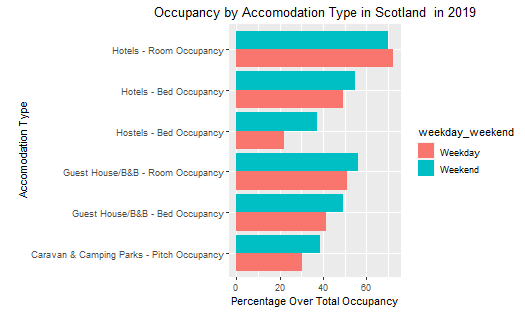

```r
scottish_accomodation_occupancy_clean %>%
  select(area,year,value,accommodation_type_and_occupancy,location, weekday_weekend) %>%
  filter(year == 2019) %>%
  filter(location == 'All') %>%
  filter(weekday_weekend != 'All') %>%
  group_by(accommodation_type_and_occupancy) %>%
  arrange(desc(value),accommodation_type_and_occupancy) %>%
  ggplot(aes(fill= weekday_weekend, y=value, x=accommodation_type_and_occupancy)) +
    geom_bar(position="dodge", stat="identity")+
 labs(
    title ="Occupancy by Accomodation Type in Scotland  in 2019",
    x = "\n Accomodation Type",
    y = "Percentage Over Total Occupancy\n") +
   coord_flip()+
  theme_update(plot.title = element_text(hjust = 1))
```

Cheap travels for long weekends. Note: difference Room and Bed occupancy, no clear but I understand that Room means the number of occupants per room but Bed means the number of occupants in a room per size bed = 1 single bed and 1 double bed means 3 max occupants